# Group 6.1 Online Education

## Project Description

1. This system will provide recommendation to users based on their preferences and selection criteria.
2. This project aims to find out the soft skills and hard skills to be required in different jobs and to map them into a study program or a course’s learning outcomes.
3. This project consists of four parts:
   - The first part is to find out the soft skills and hard skills to be required in different jobs and recommend courses to fullfil the job requirements.
   - The second part is find the skills that can be learned from specific courses, and recommend jobs that match those skills.
   - Create a classification to analyze whether the skills that can be learned in the course are more hard skills or soft skills
   - The last part is to provide some business insights to the client:
     - recommend courses in the university to help students to lean skills and recommend courses to open if the university not offer
     - recommend similar jobs to the clients when they searching for a specific job
     - recommend courses with similar content

## Project Team (Sirname Alphabetical Order):

- Gong Chuanqi
- Hong Zhenghui
- Long Kehan
- Qian Ruiling
- Yuan Zhenghao

## Part 1. Job to skills to courses

```python
# import required libraries
import numpy as np
import pandas as pd
import re
from pandas.api.types import CategoricalDtype
import matplotlib.pyplot as plt
import seaborn as sns
import pandas as pd
from sklearn.feature_extraction.text import TfidfVectorizer, CountVectorizer
from sklearn.metrics.pairwise import linear_kernel, cosine_similarity
from sklearn.feature_extraction.text import CountVectorizer
from sklearn import linear_model
from sklearn.linear_model import LogisticRegression
from sklearn.metrics import roc_curve, auc, confusion_matrix, accuracy_score, classification_report
import warnings
warnings.filterwarnings("ignore")
```

### 1. Clean data

```python
pattern = re.compile(u"[\[\"\]\'.!！●︿~。;~*'зД=つ\-Дノ→\+·②⑥:°【［•”˙×ε○↖\\、↗∧⊙⊥⑨┌╯▽罒】☆⌒∩〃￥〕ㄒㄥ〔`\[\"\?\]ò\*ω￥∀Σπ●《》……^≦～－——？\.：；‘“、……％?¥＃#@$%^&.!?]")

def cleanData(toclean):
    rt = re.sub(pattern, "", toclean)
    rt = re.sub('\n', " ", rt)
    rt = re.sub('\n', " ", rt)
    return(rt)
```

### 2. Use job requirements to find skills

```python
# read alldata.csv
df_job = pd.read_csv('alldata.csv')
df_job.head()
```

|  | position | company | description | reviews | location |
| --- | --- | --- | --- | --- | --- |
| 0 | Development Director | ALS TDI | Development Director\nALS Therapy Development ... | NaN | Atlanta, GA 30301 |
| 1 | An Ostentatiously-Excitable Principal Research... | The Hexagon Lavish | Job Description\n\n"The road that leads to acc... | NaN | Atlanta, GA |
| 2 | Data Scientist | Xpert Staffing | Growing company located in the Atlanta, GA are... | NaN | Atlanta, GA |
| 3 | Data Analyst | Operation HOPE | DEPARTMENT: Program OperationsPOSITION LOCATIO... | 44.0 | Atlanta, GA 30303 |
| 4 | Assistant Professor -TT - Signal Processing & ... | Emory University | DESCRIPTION\nThe Emory University Department o... | 550.0 | Atlanta, GA |

### 2.1 find a list all the jobs supported in the dataset

- **Please use Python 3.9.13 to run this function**
- **If you find some "str object is not callable" ERRROR in the code, please restart VS Code or Jupyter Notebook and try again**
- **If you still find this ERROR please contact us before giving any GRADE**

```python
#Built a function to find all the  jobs supported and counts
def support_jobs(job_list):
    # text cleaning
    requir=list(df_job['position'])
    requir_clean=[]
    for ix in range(len(requir)):
        tmp_sent=cleanData(str(requir[ix]).lower())
        requir_clean.append(tmp_sent)
    # count jobs
    counts_job={}
    for s in job_list:
        for sent in requir_clean:
            if s.lower() in sent:
                counts_job[s]=counts_job.get(s, 0) + 1
    cw_job = sorted([(count,s) for s,count in counts_job.items()], reverse=True)
    #print('top words and counts for jobs:')
    print('\n'.join(map(str,cw_job)))
```

```python
job_list=['Research Scientist', 'Research Analyst', 'Machine Learning Engineer', 'Clinical Data Analyst', 'Software Engineer', 'Data Scientist', 'Stability Scientist', 'Associate Scientist', 'Senior Manager', 'Research Associate', 'Senior Product Designer', 'DATA Scientist', 'Program Manager', 'Software Engineering Manager', 'General Lab Supervisor ', 'Data Scientist Lead', 'Bioinformatics Associate Scientist', 'Data Analyst', 'Data Engineer', 'Analytic Methodologist', 'Stability Scientist', 'Siri Modeling Engineer', 'Conference Projects Assistant', 'ML Engineer (SDE)', 'Senior Director', 'Copywriter', 'Video Development Editor', 'Scientist Biochemistry', 'Political Compliance Manager', 'Senior Cyber Security Researcher', 'Lead Production Associate', 'AI-Applied Scientist', 'Manager, Data Science', 'Lead Data Scientist ']
print("All jobs supported:")
support_jobs(job_list)
```

```
All jobs supported:
(1261, 'Data Scientist')
(1261, 'DATA Scientist')
(341, 'Software Engineer')
(318, 'Research Analyst')
(274, 'Research Scientist')
(186, 'Data Engineer')
(131, 'Data Analyst')
(122, 'Machine Learning Engineer')
(118, 'Research Associate')
(105, 'Associate Scientist')
(57, 'Program Manager')
(34, 'Senior Manager')
(15, 'Senior Director')
(14, 'Manager, Data Science')
(9, 'Lead Data Scientist ')
(7, 'Data Scientist Lead')
(5, 'Senior Product Designer')
(4, 'Stability Scientist')
(3, 'Software Engineering Manager')
(2, 'General Lab Supervisor ')
(2, 'Copywriter')
(2, 'Clinical Data Analyst')
(1, 'Video Development Editor')
(1, 'Siri Modeling Engineer')
(1, 'Senior Cyber Security Researcher')
(1, 'Scientist Biochemistry')
(1, 'Political Compliance Manager')
(1, 'ML Engineer (SDE)')
(1, 'Lead Production Associate')
(1, 'Conference Projects Assistant')
(1, 'Bioinformatics Associate Scientist')
(1, 'Analytic Methodologist')
```

```python
# soft skills list
counts_soft_skills={}
soft_skills_list=['Communication', 'Innovation', 'Presentation','Management', 'Leadership', 'Planning', 'Finance', 'Problem Solving', 'English Language', 'Negotiation', 'Entrepreneurship', 'Creativity', 'Strategic Management', 'Project Management', 'Change Management','Analytics']
df_soft_skills=pd.read_csv("alldata.csv")
```

```python
# count all soft skills
## text cleaning
requir=list(df_soft_skills['description'])
requir_clean=[]
for ix in range(len(requir)):
    tmp_sent=cleanData(str(requir[ix]).lower())
    requir_clean.append(tmp_sent)

for s in soft_skills_list:
    for sent in requir_clean:
        if s.lower() in sent:
            counts_soft_skills[s]=counts_soft_skills.get(s, 0) + 1

cw_soft_skills = sorted([(count,s) for s,count in counts_soft_skills.items()], reverse=True)

print('top words and counts for soft skills:')

print('\n'.join(map(str,cw_soft_skills)))
```

```
top words and counts for soft skills:
(4100, 'Communication')
(3371, 'Management')
(2184, 'Analytics')
(1712, 'Presentation')
(1668, 'Leadership')
(1337, 'Innovation')
(1167, 'Planning')
(847, 'Problem Solving')
(664, 'Finance')
(627, 'Project Management')
(388, 'Creativity')
(110, 'Negotiation')
(81, 'Change Management')
(33, 'English Language')
(22, 'Entrepreneurship')
(5, 'Strategic Management')
```

### 2.2.1 A Barplot for soft skills

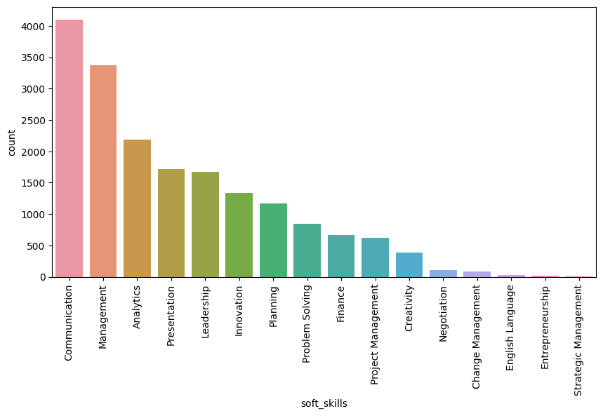

```python
#convert cw_soft_skills to dataframe
df_soft_skills=pd.DataFrame(cw_soft_skills, columns=['count', 'soft_skills'])
#drwa a barplot
plt.figure(figsize=(10,5))
sns.barplot(x='soft_skills', y='count', data=df_soft_skills)
plt.xticks(rotation=90)
plt.show()
```

### 2.3 count all hard skills in the dataset

```python
# hard skills list
counts_hard_skills={}
hard_skills_list=['Python Programming', 'Statistics', 'Statistical Hypothesis Testing', 'Data Cleansing', 'Tensorflow', 'Machine Learning', 'Data Analysis', 'Data Visualization', 'Cloud Computing', 'R Programming', 'Data Science', 'Computer Programming', 'Deep Learning', 'Data Analysis', 'SQL', 'Regression Analysis', 'Algorithms', 'JavaScript']
df_hard_skills=pd.read_csv("alldata.csv")
```

```python
requir=list(df_hard_skills['description'])
requir_clean=[]
for ix in range(len(requir)):
    tmp_sent=cleanData(str(requir[ix]).lower())
    requir_clean.append(tmp_sent)

for s in hard_skills_list:
    for sent in requir_clean:
        if s.lower() in sent:
            counts_hard_skills[s]=counts_hard_skills.get(s, 0) + 1

cw_hard_skills = sorted([(count,s) for s,count in counts_hard_skills.items()], reverse=True)

print('top words and counts for hard skills:')

print('\n'.join(map(str,cw_hard_skills)))
```

```
top words and counts for hard skills:
(2840, 'Data Analysis')
(2452, 'Machine Learning')
(2110, 'Statistics')
(1924, 'SQL')
(1575, 'Data Science')
(1516, 'Algorithms')
(592, 'Deep Learning')
(540, 'Data Visualization')
(407, 'Tensorflow')
(358, 'JavaScript')
(225, 'R Programming')
(165, 'Cloud Computing')
(39, 'Computer Programming')
(36, 'Regression Analysis')
(36, 'Python Programming')
(25, 'Data Cleansing')
(6, 'Statistical Hypothesis Testing')
```

### 2.2.1 A Barplot for hard skills

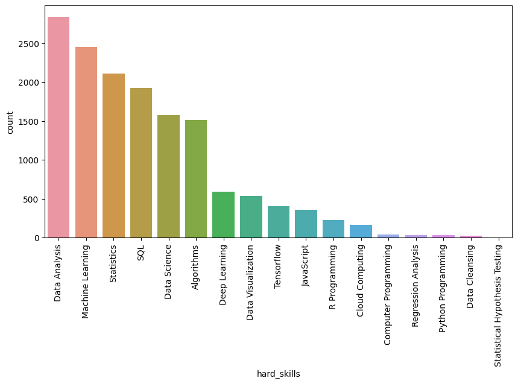

```python
# convert cw_hard_skills to dataframe
df_hard_skills=pd.DataFrame(cw_hard_skills, columns=['count', 'hard_skills'])
# draw a barplot
plt.figure(figsize=(10,5))
sns.barplot(x='hard_skills', y='count', data=df_hard_skills)
plt.xticks(rotation=90)
plt.show()
```

### 2.4 find the most common hard and soft skills in the specific job

```python
#The function to find most important skills for a certain job
hard_skills_required=[]
soft_skills_required=[]

def Find_skills(job_name):

    # read job dataset
    df_job=pd.read_csv("alldata.csv")
    # filter jobs whose name contains "job_name"
    df_job['job_name_lower'] = df_job.apply (lambda row: str(row.position).lower(), axis=1)
    df2_job=df_job[df_job['job_name_lower'].str.contains(job_name)]
    # print("Matching jobs:")
    # df2_job.head()

    #count the number of rows for job "data analyst"
    print("There are",len(df2_job),"matching jobs find.\n") #With more matching jobs, more reliable
    ## text cleaning
    requir=list(df2_job['description'])
    requir_clean=[]
    for ix in range(len(requir)):
        tmp_sent=cleanData(requir[ix].lower())
        requir_clean.append(tmp_sent)

    # the 90 most popular skills are Classified as softskills and hard skills from course analysis
    softskills = ["grammar", "writing","public health", "problem solving","art history","art","history","gratitude","positive psychology","brand management","communication","biology","planning","meditation","music","animal behavior","english language","english grammar","law","goal setting","psychology","negotiation","management","finance","creativity","graphics","entrepreneurship","change management","statistics","strategic management"]
    hardskills = ["tensorflow","deep learning","microsoft excel","python syntax and semantics","python programming","programming language","artificial neural network","computer programming","algorithms","objectoriented programming (oop)","microbiology","machine learning","financial accounting","financial statement","accounting","nutrition","financial markets","corporate finance","international law","data analysis","data visualization (dataviz)","cybersecurity","cryptography","business strategy","innovation","energy","project management","project planning","marketing","lean six sigma","six sigma","business model","data management","sql","project","teaching","strategic thinking","leadership","cloud computing","r programming","mythology","artificial intelligence (ai)","html","cascading style sheets (ccs)","decisionmaking","human resources (hr)","investment","social network","risk management","mathematical optimization","rstudio","data cleansing","agile software development","linear regression","data science","information security (infosec)","google cloud platform","analytics","regression analysis","data virtualization"]

    # count and sort the hard skills
    counts_hard={}
    for s in hardskills:
        for sent in requir_clean:
            if s.lower() in sent:
                counts_hard[s]=counts_hard.get(s, 0) + 1
    cw_hard = sorted([(count,s) for s,count in counts_hard.items()], reverse=True)
    for i in cw_hard[:5]:
        hard_skills_required.append(i) #use a list to store important hard skills

    print('Most important hard skills and counts for', job_name, " :")
    print('\n'.join(map(str,cw_hard[:5])))

    # count and sort the soft skills
    counts_soft={}
    for s in softskills:
        for sent in requir_clean:
            if s.lower() in sent:
                counts_soft[s]=counts_soft.get(s, 0) + 1
    cw_soft = sorted([(count,s) for s,count in counts_soft.items()], reverse=True)
    for i in cw_soft[:5]:
        soft_skills_required.append(i) #use a list to store important soft skills
    print('\n')
    print('Most important soft skills and counts for', job_name, " :")
    print('\n'.join(map(str,cw_soft[:5])))
```

#### 2.4.1 input the job and give the skills required

```python
# test the above code
job_input = "Software engineer"
job_name=str(job_input).lower()
Find_skills(job_name)
print("\n")
print("Hard Skills are " + str(hard_skills_required) + "\n")#stored important hard_skills_required
print("Soft Skills are " + str(soft_skills_required))#stored important soft_skills_required
```

```
There are 341 matching jobs find.

Most important hard skills and counts for software engineer  :
(166, 'machine learning')
(144, 'project')
(132, 'algorithms')
(115, 'sql')
(93, 'analytics')


Most important soft skills and counts for software engineer  :
(309, 'art')
(150, 'communication')
(102, 'management')
(63, 'law')
(46, 'writing')


Hard Skills are [(166, 'machine learning'), (144, 'project'), (132, 'algorithms'), (115, 'sql'), (93, 'analytics')]

Soft Skills are [(309, 'art'), (150, 'communication'), (102, 'management'), (63, 'law'), (46, 'writing')]
```

### 2.5 Data Visualization

#### 2.5.1 Hard skills bar chart

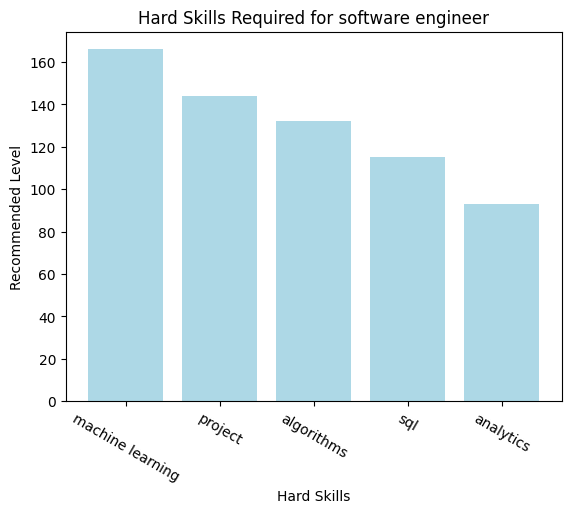

```python
# draw a bar chart for hard_skills_required
x = [i[1] for i in hard_skills_required]
y = [i[0] for i in hard_skills_required]
plt.bar(x, y)
# label the x axes as hard skills
plt.xlabel('Hard Skills')
# label the y axes as number of jobs
plt.ylabel('Recommended Level')
# rotate the x axes labels
plt.xticks(rotation=330)
# change the color of the bars to red
plt.bar(x, y, color='lightblue')
plt.title("Hard Skills Required for " + job_name)
plt.show()
```

#### 2.5.2 Soft skills bar chart

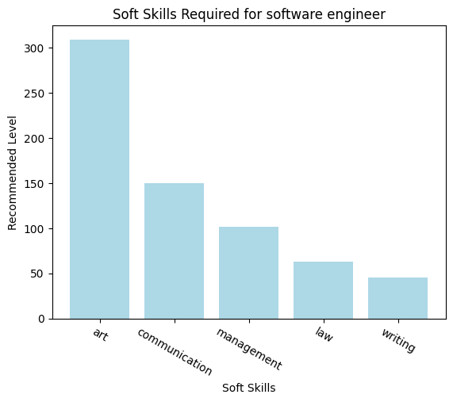

```python
# draw a bar chart for soft_skills_required
x = [i[1] for i in soft_skills_required]
y = [i[0] for i in soft_skills_required]
plt.bar(x, y)
# label the x axes as soft skills
plt.xlabel('Soft Skills')
# label the y axes as number of jobs
plt.ylabel('Recommended Level')
plt.xticks(rotation=330)
plt.bar(x, y, color='lightblue')
plt.title("Soft Skills Required for " + job_name)
plt.show()
```

### 3. Use skills to recommend courses

### 3.1 Organize the data for better searching

We rank the data by this sequence:

1. Course Rating
2. Course Difficulty (Beginner, Intermediate, Advanced, Mixed)
3. Enrollment students count
4. Number of students who rated the course

```python
# read the dataset
df = pd.read_csv("coursera-courses.csv")

# delete unused columns
df.drop(["course_url"], axis=1, inplace = True)
df.drop(["description"], axis=1, inplace = True)
df.drop(["percentage_of_new_career_starts"], axis=1, inplace = True)
df.drop(["percentage_of_pay_increase_or_promotion"], axis=1, inplace = True)

# remove non-courses options
df2 = df[~df["learning_product_type"].isin(["PROFESSIONAL CERTIFICATE", "SPECIALIZATION"])]

# re-order the by rate, difficulty, enrolled_student_count, and course_rated_by
difficulty_order = CategoricalDtype(
    ['Beginner', 'Intermediate', 'Advanced', 'Mixed'],
    ordered=True
)
df2['course_difficulty'] = df2['course_difficulty'].astype(difficulty_order)
df2 = df2.sort_values(by=["course_rating", "course_difficulty", "enrolled_student_count","course_rated_by" ], ascending = (False,True, False, False))
df2 = df2.drop(df2[df2["skills"] == "['Missing']"].index)
df2 = df2.reset_index(drop=True)

# clean all punctuations in the dataframe
for i in range(len(df2)):
    df2.loc[i, "skills"] = cleanData(df2.loc[i, "skills"])
    df2.loc[i, "instructors"] = cleanData(df2.loc[i, "instructors"])

# remove NaN courses
df2 = df2.dropna()
df2 = df2.reset_index(drop=True)
```

### 3.2 Data processing

- The 90 most popular skills are Classified as softskills and hard skills.
- enrolled_student_count_list is used to store the number of enrolled students of each course.
- course_value is used to store the value of each course depending on the skills it offers.
- positibe_rate_dict is used to store the positive users of each course

```python
# a list call allskill to store the skills all our course offers
allList = []
for i in range(len(df2)):
    tempList = df2.loc[i, "skills"].split(', ')
    for j in tempList:
        j = j.lower()
        if j not in allList:
            allList.append(j)

# sort the allList by first letter
allList = sorted(allList,key = lambda i:i[0])
# now we have allList sorted by first letter


# a dict call skillDict to store the skills and how many courses offer it
alldict = {}
for i in range(len(df2)):
    tempList = df2.loc[i, "skills"].split(', ')
    for j in tempList:
        j = j.lower()
        if j not in alldict:
            alldict[j] = 1
        else:
            alldict[j] = alldict[j] + 1



# so now we have a dict called alldict, which stores the skills and how many courses offer it
# from this we can get the most popular skills and the least popular skills
# the 90 most popular skills are Classified as softskills and hard skills

softskills = ["grammar", "writing","public health", "problem solving","art history","art","history","gratitude","positive psychology","brand management","communication","biology","planning","meditation","music","animal behavior","english language","english grammar","law","goal setting","psychology","negotiation","management","finance","creativity","graphics","entrepreneurship","change management","statistics","strategic management"]
hardskills = ["tensorflow","deep learning","microsoft excel","python syntax and semantics","python programming","programming language","artificial neural network","computer programming","algorithms","objectoriented programming (oop)","microbiology","machine learning","financial accounting","financial statement","accounting","nutrition","financial markets","corporate finance","international law","data analysis","data visualization (dataviz)","cybersecurity","cryptography","business strategy","innovation","energy","project management","project planning","marketing","lean six sigma","six sigma","business model","data management","sql","project","teaching","strategic thinking","leadership","cloud computing","r programming","mythology","artificial intelligence (ai)","html","cascading style sheets (ccs)","decisionmaking","human resources (hr)","investment","social network","risk management","mathematical optimization","rstudio","data cleansing","agile software development","linear regression","data science","information security (infosec)","google cloud platform","analytics","regression analysis","data virtualization"]

# course_value is used to store the value of each course depending on the skills it offers
# because hard skills are more valuable than soft skills, we give hard skills a higher value, but the value is not static so you can change it
course_value = {}
for i in range(len(df2)) :
    tempList = df2.loc[i, "skills"].split(', ')
    course_value[df2.loc[i, "course_name"]] = 0
    for j in tempList :
        j = j.lower()
        if j in softskills :
            course_value[df2.loc[i, "course_name"]] = course_value[df2.loc[i, "course_name"]] + 4
        elif j in hardskills :
            course_value[df2.loc[i, "course_name"]] = course_value[df2.loc[i, "course_name"]] + 2
        else :
            course_value[df2.loc[i, "course_name"]] = course_value[df2.loc[i, "course_name"]] + 1


# positibe_rate_dict is used to store the positive users of each course
# as the max course_rate is 4.9, so we set the full rate is 5, so we divide it by 5
positive_rate_dict = {}
for i in range(len(df2)) :
    course_rate = df2.loc[i, "course_rating"]
    course_rated_by = df2.loc[i, "course_rated_by"]
    positive_rate_dict[df2.loc[i, "course_name"]] = course_rate * course_rated_by / 5
#print(positive_rate_dict)


# enrolled_student_count_list is used to store the enrolled_student_count of each course
enrolled_student_count_list = {}
for i in range(len(df2)) :
    enrolled_student_count_list[df2.loc[i, "course_name"]] = df2.loc[i, "enrolled_student_count"]

enrolled_student_count_dict = enrolled_student_count_list
#sort the enrolled_student_count_list by value
enrolled_student_count_list = sorted(enrolled_student_count_list.items(), key = lambda kv:(kv[1], kv[0]), reverse = True)
# now we have all the data we need, we can start to build our recommendation system
```

### 3.3 Search Engine

Search a course with a key word, also provide courses with the similar skills.search a course with a key word, also provide courses with the similar skills. Provide 10 courses with the keyword in name and 10 course in skills by default. A statistical model is used to decide the sequence of the output

advanceSearch: Use Pearson correlation analysis to find a course that matches the hard skills and soft skills best

```python
import operator
def basicSearch(keyword, num=10):
    out=[]
    for item in course_value.keys():
        if operator.contains(item, keyword):
            out.append(item)
            if len(out) >= num:
                break

    df3=df2[df2['skills'].str.contains(keyword)]
    related = []
    i = 0
    #print(df3)
    while len(related) <= num:
        course = df3.iloc[i, 0]

        if i == 0:
            print(course)
        i += 1
        if i >= len(df3):
            break


        if course in out:
            continue
        else:
            related.append(course)

    return out, related
```

```python
keyword = "Communication"
out, related = basicSearch(keyword)
print("The courses with keyword [", keyword, "] are: ")
print(out)
print("You may also interested in courses with [", keyword, "] as a skill: ")
print(related)
```

```
Writing in the Sciences
The courses with keyword [ Communication ] are:
['Communication Strategies for a Virtual Age', 'Improving Communication Skills', 'Data Visualization and Communication with Tableau']
You may also interested in courses with [ Communication ] as a skill:
['Writing in the Sciences', 'Positive Psychology: Resilience Skills', 'Business Writing', 'IBM Customer Engagement Specialist Professional Certificate', 'English for Career Development', 'Successful Negotiation: Essential Strategies and Skills', 'Chinese for Beginners', 'Negociación exitosa: Estrate…
```

```python
def getVector(course, skill):
    have = list(df2[df2['course_name'].str.fullmatch(course)]['skills'])
    vector = [0,0,0,0,0,0,0,0,0,0]
    for i in range(10):
        if skill[i] in have:
            vector[i] = 1

    return np.array(vector)
```

```python
#import scripy.stats

def advancedSearch(hard,soft):
    # get courses with a skill
    name = []
    for i in range(5):
        name.append(hard[i][1])
        name.append(soft[i][1])
    skill = np.array([25,24,23,22,21,20,19,18,17,16])
    courses = []
    for i in range(10):
        df4 = df2[df2['skills'].str.contains(name[i])]
        ava = list(df4['course_name'])
        for ele in ava:
            if ele not in courses:
                courses.append(ele)
    print("Courses with a skill: ", courses)
    print()

    # use Pearson correlation to find the best course
    collection = {}
    for ele in courses:
        vector = getVector(ele, name)
        collection[ele] = np.corrcoef(vector, skill)[0][1]
    m = max(collection.keys(),key=(lambda x:collection[x]))
    print("The best suited course is: ", m)

advancedSearch(hard_skills_required, soft_skills_required)
```

```
Courses with a skill:  ['AI For Medical Treatment', 'Excel Skills for Business: Essentials', 'Excel Skills for Business: Intermediate I', 'Digital Product Management: Modern Fundamentals', 'Engineering Project Management: Initiating and Planning', 'Renewable Energy and Green Building Entrepreneurshi…

The best suited course is:  AI For Medical Treatment
```

### 3.4 Data Visualization

#### 3.4.1 Plot the pie chart for the most popular course in the searched keyword

```
{'Foundations of Everyday Leadership': 65000.0, 'Negociación exitosa: Estrategias y habilidades esenciales (en español)': 96000.0, 'Data Visualization and Communication with Tableau': 130000.0, 'Writing in the Sciences': 140000.0, 'Chinese for Beginners': 750000.0, 'Successful Negotiation: Essential…
```

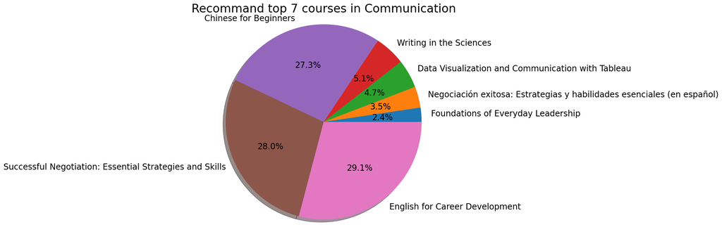

```python
ans = {}
for item in out:
    ans[item] = enrolled_student_count_dict[item]
for item in related:
    ans[item] = enrolled_student_count_dict[item]

ans = dict(sorted(ans.items(),  key=lambda d: d[1], reverse=False)[len(ans) - 7:])
print(ans)
label = list(ans.keys())
value = list(ans.values())

plt.pie(value,labels = label,
        startangle=0,textprops={'fontsize': 17},
        shadow=True, autopct='%1.1f%%');
plt.title('Recommand top ' + str(len(value)) + " courses in " + keyword,fontsize=24) ;
plt.axis('equal');

plt.gcf().set_size_inches(8, 8)

plt.show()
```

#### 3.4.2 Plot the histogram of skill points for course in the searched courses

```
[4, 13, 6, 10, 14, 13, 10, 13, 10, 10, 13, 6, 9, 11]
```

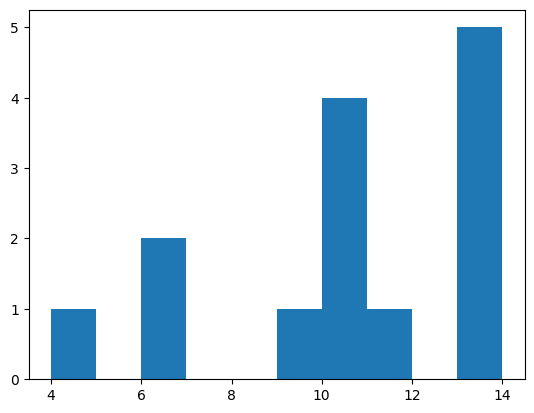

```python
ans = {}
for item in out:
    ans[item] = course_value[item]
for item in related:
    ans[item] = course_value[item]

value = list(ans.values())
print(value)

plt.hist(value)
```

```python
def output(iterate, num):
    out = []
    i = 0
    for item in iterate:
        if i== 20:
            break
        out.append((item, iterate[item]))
        i+=1
    return out
```

```python
def toNum(string):
    index = 0
    for i in range(len(string)):
        if string[i] == " ":
            index = i
            break
    return int(string[:index])

course_spend_hours = {}
for i in range(len(df2)) :
    course_spend_hours[df2.loc[i, "course_name"]] = toNum(df2.loc[i, "estimated_time_to_complete"])

print("time: ", output(course_spend_hours, 20))
```

```
time:  [('First Step Korean', 12), ('COVID-19 Contact Tracing', 5), ('Introduction to Psychology', 26), ('Improving Deep Neural Networks: Hyperparameter tuning, Regularization and Optimization', 18), ('Excel Skills for Business: Essentials', 22), ('Aprendiendo a aprender: Poderosas herramientas ment…
```

```
R^2 is:  0.5139307292666336
```

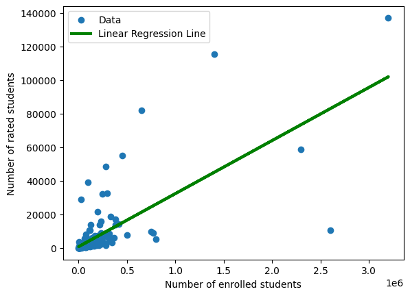

```python
independent = []
dependent = []
test = []
for i in range(len(df2) // 2):
    x = []
    y = []
    #y.append(df2.loc[i, "course_rating"])
    y.append(df2.loc[i, "course_rated_by"])
    x.append(df2.loc[i, "enrolled_student_count"])
    #x.append(course_spend_hours[df2.loc[i, "enrolled_student_count"]])
    #y.append(course_value[df2.loc[i, "course_name"]])
    independent.append(x)
    dependent.append(y)

for i in range(len(df2) // 2):
    x = []
    x.append(course_spend_hours[df2.loc[i + len(df2) // 2, "course_name"]])
    test.append(x)

#print(independent)
#print(dependent)

# get the linear regression model for independent and dependent variables
model=linear_model.LinearRegression()
X = np.asarray(independent)
Y = np.asarray(dependent)
model.fit(X,Y)

# get the R^2 value
print("R^2 is: ", model.score(X, Y))
# plot the linear regression line use green color
plt.scatter(X, Y)
plt.plot(X,model.predict(X),color="green",linewidth=3.0,linestyle="-")
# label the x and y axis
plt.xlabel("Number of enrolled students")
plt.ylabel("Number of rated students")
plt.legend(["Data","Linear Regression Line"],loc=0)
plt.show()
```

## Part 2. Courses to Skills to Job

This part allows clients to input a course they attend, and the system will recommend a suitable job to them through the skills contained in the lessons learned.

### 2.1 Clean the data of "coursera-courses.csv"

```python
# clean Data
pattern = re.compile(u"[\[\"\]\'.!！●︿~。;~*'зД=つ\-Дノ→\+·②⑥:°【［•”˙×ε○↖\\、↗∧⊙⊥⑨┌╯▽罒】☆⌒∩〃￥〕ㄒㄥ〔`\[\"\?\]ò\*ω￥∀Σπ●《》……^≦～－——？\.：；‘“、……％?¥＃#@$%^&.!?]")
def cleanData(toclean):
    rt = re.sub(pattern, "", toclean)
    rt = re.sub('\n', " ", rt)
    rt = re.sub('\n', " ", rt)
    return(rt)

# read the dataset
df = pd.read_csv("coursera-courses.csv")

# delete unused columns
df.drop(["course_url"], axis=1, inplace = True)
df.drop(["description"], axis=1, inplace = True)
df.drop(["percentage_of_new_career_starts"], axis=1, inplace = True)
df.drop(["percentage_of_pay_increase_or_promotion"], axis=1, inplace = True)

# remove non-courses options
df2 = df[~df["learning_product_type"].isin(["PROFESSIONAL CERTIFICATE", "SPECIALIZATION"])]

# re-order the by rate, difficulty, enrolled_student_count, and course_rated_by
difficulty_order = CategoricalDtype(
    ['Beginner', 'Intermediate', 'Advanced', 'Mixed'],
    ordered=True
)
df2['course_difficulty'] = df2['course_difficulty'].astype(difficulty_order)
df2 = df2.sort_values(by=["course_rating", "course_difficulty", "enrolled_student_count","course_rated_by" ], ascending = (False,True, False, False))
df2 = df2.drop(df2[df2["skills"] == "['Missing']"].index)
df2 = df2.reset_index(drop=True)

# clean all punctuations in the dataframe
for i in range(len(df2)):
    df2.loc[i, "skills"] = cleanData(df2.loc[i, "skills"])
    df2.loc[i, "instructors"] = cleanData(df2.loc[i, "instructors"])

# remove NaN courses
df2 = df2.dropna()
df2 = df2.reset_index(drop=True)
```

### 2.2 Get the skills by input the course name

- The customer could input a course name, for exsample: psychology.
- The code will find out the course that is closest to the user input, and give the course a score by rate.
- Then from the course, we can get the dictionary called course_skill to store the skills and the course rate.
- The output is the bar chart of the course and its rate.

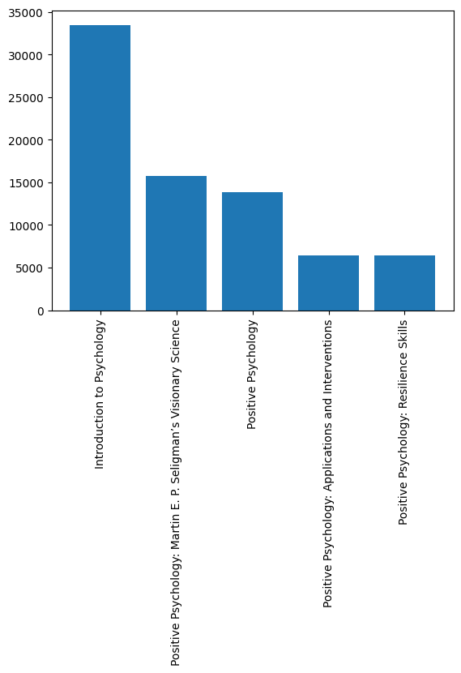

```python
# course_name is the input of user
# for example, we use "psychology" as the input
course_name = "psychology"

# find the course by vague name
course = df2[df2["course_name"].str.contains(course_name, case=False)]
course = course.reset_index(drop=True)

#sort them by rating * course_rated_by
course["rating"] = course["course_rating"] * course["course_rated_by"]
course = course.sort_values(by=["rating"], ascending = False)

# find the skill and put into a dictionary, the key is name, the value is list of skills
course_skill = {}
for i in range(len(course)):
    course_skill[course.loc[i, "rating"]] = course.loc[i, "skills"].split(", ")

# draw a bar chart to show the courses and their rating
import matplotlib.pyplot as plt
plt.bar(course["course_name"], course["rating"])
plt.xticks(rotation=90)
plt.show()
```

### 2.2 Clean the data of "alldata.csv"

```python
PUNC = ["!", '"', "#", "$", "%", "&", "'", "(", ")",
        "*", "+", ",", "-", ".", "/", ":", ";",
        "<", "=", ">", "?", "@", "[", "]", "^", "_",
        "`", "{", "}", "|", "~"]

def clean_line(a):

    now = a.lower()

    for i in PUNC:
        if i in now:
            now = now.replace(i, "")
        if '  ' in now:
            now = now.replace('  ', " ")
    now = now.strip()
    return now


def is_similar(a,b):


    now = a.split(' ')
    old = b.split(' ')

    duplicate = [k for k in now if k in old]
    if len(duplicate) >= min(len(now),len(old)) * 0.6:
        return True
    return False

data = pd.read_csv('alldata.csv')
```

### 2.3 Recommend the jobs

```python
skills={}
for i in course_skill:
    for j in course_skill[i]:
        skills[j] = i

print('Please wait while we calculate your suitable jobs')


length = data.shape[0]
jobs = []
skills_count = {}
skills_recommend = []


proficiency = []
for i in skills:
    proficiency.append(skills[i])

for i in range(length):

    job = data.iloc[i, 0]
    description = data.iloc[i, 2]
    skills_count[job]=[]


    if type(description) != float and type(job) != float:

        for i in skills:
            skills_count[job].append(description.count(i))


        similar = False
        for j in jobs:

            similar = is_similar(clean_line(job), clean_line(j))

            if similar:

                for idx in range(len(proficiency)):
                    skills_count[j][idx] = skills_count[j][idx] + skills_count[job][idx]

                recommend = 0
                for i in range(len(proficiency)):
                    fit_ratio = skills_count[j][i]
                    recommend = recommend + fit_ratio * proficiency[i]  # 累加

                skills_recommend[jobs.index(j)]=recommend

                if len(j)>len(job):
                    jobs[jobs.index(j)] = job
                    skills_count[job] = skills_count[j]
                break

        if not similar:


            recommend = 0
            for i in range(len(proficiency)):
                fit_ratio = skills_count[job][i]
                recommend = recommend + fit_ratio * proficiency[i]  # 累加


            skills_recommend.append(recommend)
            jobs.append(job)


recommend_data = pd.DataFrame({'job': jobs,'recommend' : skills_recommend,})

res = recommend_data.sort_values(by='recommend', ascending=False)


print('The following are recommended occupations')
jobs_list = []
ratios = []
for i in range(10):
    job = res.iloc[i, 0]


    if res.iloc[0, 1] == 0:
        ratio = 100
    else:
        ratio = (res.iloc[i, 1] * 100 / res.iloc[0, 1]).round(2)


    if ratio == 0:
        break

    print(res.iloc[i, 0], ratio)


    jobs_list.append(job)
    ratios.append(ratio)

    if len(jobs_list) == 10:
        break
```

```
Please wait while we calculate your suitable jobs
The following are recommended occupations
Director 100.0
Senior Program Manager 74.95
Analyst 60.4
Researcher 57.05
Product Manager 49.86
Epidemiologist 43.35
Research Staff Member, AI Learning 41.34
Senior Java Engineer 40.72
Consultancy: Urban Planning, PSN Section, DRP - NYHQ, Requisition #514770 39.47
Research Associate 36.74
```

### 2.3 Visualization

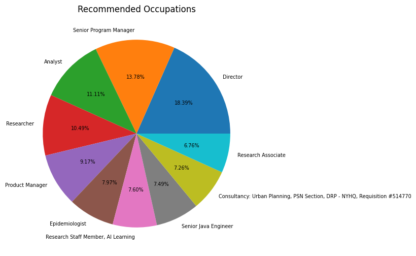

```python
plt.figure(figsize=(10, 6))
plt.pie(ratios,
        labels=jobs_list,
        autopct='%0.2f%%',
        textprops={'fontsize': 7},
        )

plt.title('Recommended Occupations')
plt.show()
```

# Part 3. Use classification model to analyze the learning outcomes

Use classification model to classify the hard skills and soft skills of the courses into the program learning outcomes.

#### 3.1 Read dataset

```python
df_course=pd.read_csv("coursera-courses.csv")
```

#### 3.2 Built a skill vector

#### use 0 and 1 to indicate whether the skills in engaged in this specific course

```python
#preprocessing the using columns
df_course['skills'] = df_course['skills'].fillna('')
df_course['skills']=df_course['skills'].str.lower()
df_course['course_name']=df_course['course_name'].str.lower()
print(df_course.shape)
```

```
(1000, 14)
```

```python
#Find all the skills we can learn from these courses
Allskills=[]
skills=list(df_course['skills'])
#print(len(skills))
for i in range(len(skills)):
    tmp=cleanData(skills[i]).split(",")
    #print(tmp)
    for j in tmp:
        #print("single",j)
        Allskills.append(j)
#print(len(Allskills))
realskills=set(Allskills)# remove the duplicate skills
realskills.remove('missing')#remove the "Missing"
print("There are total ",len(realskills)," skills provided.")
cols=list(realskills)
```

```
There are total  2031  skills provided.
```

```python
# Make the a new data frame that stores the skills, set them all to 0 first
data = np.zeros((1000,2031))
#print(data)
df = pd.DataFrame(data, columns = cols)
# df = pd.DataFrame(data, columns = cols,index=rows)
```

```python
# Use the new data frame to store what skills we can obtain through take the course and  1 indicate that the specific skill is engaged, while 0 means not
for i in range(len(skills)):
    tmp=cleanData(skills[i]).split(",")
    #print(tmp)
    for j in tmp:
        df.loc[i,j]=1
        #print("single",j)
del df["missing"]
df
```

|  | news writing | calculating net present value of a project | outbreak investigation | predictive modelling | information visualization (infovis) | statistical analysis skills | listening | business value | veterinary | smart city | ... | reproductive health | how to ask insightful questions about the safety of cannabis and cbd products | python syntax and semantics | genetic analysis | clinical data management | keyword research | natural language extraction | reinforcement learning | web design | lean project management |
| --- | --- | --- | --- | --- | --- | --- | --- | --- | --- | --- | --- | --- | --- | --- | --- | --- | --- | --- | --- | --- | --- |
| 0 | 0.0 | 0.0 | 0.0 | 1.0 | 0.0 | 0.0 | 0.0 | 0.0 | 0.0 | 0.0 | ... | 0.0 | 0.0 | 0.0 | 0.0 | 0.0 | 0.0 | 0.0 | 0.0 | 0.0 | 0.0 |
| 1 | 0.0 | 0.0 | 0.0 | 0.0 | 0.0 | 0.0 | 0.0 | 0.0 | 0.0 | 0.0 | ... | 0.0 | 0.0 | 0.0 | 0.0 | 0.0 | 0.0 | 0.0 | 0.0 | 0.0 | 0.0 |
| 2 | 0.0 | 0.0 | 0.0 | 0.0 | 0.0 | 0.0 | 0.0 | 0.0 | 0.0 | 0.0 | ... | 0.0 | 0.0 | 0.0 | 0.0 | 0.0 | 0.0 | 0.0 | 0.0 | 0.0 | 0.0 |
| 3 | 0.0 | 0.0 | 0.0 | 0.0 | 0.0 | 0.0 | 0.0 | 0.0 | 0.0 | 0.0 | ... | 0.0 | 0.0 | 0.0 | 0.0 | 0.0 | 0.0 | 0.0 | 0.0 | 0.0 | 0.0 |
| 4 | 0.0 | 0.0 | 0.0 | 0.0 | 0.0 | 0.0 | 0.0 | 0.0 | 0.0 | 0.0 | ... | 0.0 | 0.0 | 0.0 | 0.0 | 0.0 | 0.0 | 0.0 | 0.0 | 0.0 | 0.0 |
| ... | ... | ... | ... | ... | ... | ... | ... | ... | ... | ... | ... | ... | ... | ... | ... | ... | ... | ... | ... | ... | ... |
| 995 | 0.0 | 0.0 | 0.0 | 0.0 | 0.0 | 0.0 | 0.0 | 0.0 | 0.0 | 0.0 | ... | 0.0 | 0.0 | 0.0 | 0.0 | 0.0 | 0.0 | 0.0 | 0.0 | 0.0 | 0.0 |
| 996 | 0.0 | 0.0 | 0.0 | 0.0 | 0.0 | 0.0 | 0.0 | 0.0 | 0.0 | 0.0 | ... | 0.0 | 0.0 | 0.0 | 0.0 | 0.0 | 0.0 | 0.0 | 0.0 | 0.0 | 0.0 |
| 997 | 0.0 | 0.0 | 0.0 | 0.0 | 0.0 | 0.0 | 0.0 | 0.0 | 0.0 | 0.0 | ... | 0.0 | 0.0 | 0.0 | 0.0 | 0.0 | 0.0 | 0.0 | 0.0 | 0.0 | 0.0 |
| 998 | 0.0 | 0.0 | 0.0 | 0.0 | 0.0 | 0.0 | 0.0 | 0.0 | 0.0 | 0.0 | ... | 0.0 | 0.0 | 0.0 | 0.0 | 0.0 | 0.0 | 0.0 | 0.0 | 0.0 | 0.0 |
| 999 | 0.0 | 0.0 | 0.0 | 0.0 | 0.0 | 0.0 | 0.0 | 0.0 | 0.0 | 0.0 | ... | 0.0 | 0.0 | 0.0 | 0.0 | 0.0 | 0.0 | 0.0 | 0.0 | 0.0 | 0.0 |

1000 rows × 2031 columns

#### 3.3 Simulate the scale of learning outcomes of courses

If through this course we can gain mainly hard skill, learning_outcomes label is 1; if this course teaches soft skills more, give a 0 Simulate the scale of learning outcomes of courses

```python
#Simulate the scale of learning outcomes of  courses
# If through this course we can gain mainly hard skill, learning_outcomes label is 1; if this course teaches soft skills more, give a 0
hardSkills=[' java programming','logistic regression',' Python Programming',' python programming', ' machine learning', ' linux', 'json',' ipython', ' Statistics',' Statistical Hypothesis Testing', ' Data Cleansing', ' Tensorflow', ' Machine Learning', ' Data Analysis', ' Data Visualization', ' Cloud Computing', ' R Programming', ' Data Science', ' Computer Programming', ' Deep Learning', ' Data Analysis', ' SQL', ' Regression Analysis', ' Algorithms', ' JavaScript']
softSkills= [' Communication', ' Innovation', ' Presentation',' Management', ' Leadership', ' Planning', ' Finance', ' Problem Solving', ' English Language', ' Negotiation', ' Entrepreneurship', 'Creativity', ' Strategic Management', ' Project Management', 'Change Management',' Analytics']
for i in hardSkills:
    i =i.lower
for i in softSkills:
    i=i.lower
for i in range(len(skills)):
    tmp=cleanData(skills[i]).split(",")
    counthard=0
    countsoft=0
    #print(tmp)
    for j in tmp:
        if j in hardSkills:
            counthard+=1 #count the hard skills encounter
        if j in softSkills:
            countsoft+=1 #count the soft skills encounter

    #print("hard", counthard)
    #print("Soft", countsoft)
    if (counthard>countsoft): # compare the hard skills number to the soft skills number,label the learning outcome
        df.loc[i,"learning_outcome"]=1
    else:
        df.loc[i,"learning_outcome"]=0
```

```python
row=list(df_course['course_name'])
df.index=row
df.head(20)
```

|  | news writing | calculating net present value of a project | outbreak investigation | predictive modelling | information visualization (infovis) | statistical analysis skills | listening | business value | veterinary | smart city | ... | how to ask insightful questions about the safety of cannabis and cbd products | python syntax and semantics | genetic analysis | clinical data management | keyword research | natural language extraction | reinforcement learning | web design | lean project management | learning_outcome |
| --- | --- | --- | --- | --- | --- | --- | --- | --- | --- | --- | --- | --- | --- | --- | --- | --- | --- | --- | --- | --- | --- |
| ibm data science | 0.0 | 0.0 | 0.0 | 1.0 | 0.0 | 0.0 | 0.0 | 0.0 | 0.0 | 0.0 | ... | 0.0 | 0.0 | 0.0 | 0.0 | 0.0 | 0.0 | 0.0 | 0.0 | 0.0 | 1.0 |
| introduction to data science | 0.0 | 0.0 | 0.0 | 0.0 | 0.0 | 0.0 | 0.0 | 0.0 | 0.0 | 0.0 | ... | 0.0 | 0.0 | 0.0 | 0.0 | 0.0 | 0.0 | 0.0 | 0.0 | 0.0 | 1.0 |
| python for everybody | 0.0 | 0.0 | 0.0 | 0.0 | 0.0 | 0.0 | 0.0 | 0.0 | 0.0 | 0.0 | ... | 0.0 | 0.0 | 0.0 | 0.0 | 0.0 | 0.0 | 0.0 | 0.0 | 0.0 | 1.0 |
| google it support | 0.0 | 0.0 | 0.0 | 0.0 | 0.0 | 0.0 | 0.0 | 0.0 | 0.0 | 0.0 | ... | 0.0 | 0.0 | 0.0 | 0.0 | 0.0 | 0.0 | 0.0 | 0.0 | 0.0 | 1.0 |
| deep learning | 0.0 | 0.0 | 0.0 | 0.0 | 0.0 | 0.0 | 0.0 | 0.0 | 0.0 | 0.0 | ... | 0.0 | 0.0 | 0.0 | 0.0 | 0.0 | 0.0 | 0.0 | 0.0 | 0.0 | 1.0 |
| the science of well-being | 0.0 | 0.0 | 0.0 | 0.0 | 0.0 | 0.0 | 0.0 | 0.0 | 0.0 | 0.0 | ... | 0.0 | 0.0 | 0.0 | 0.0 | 0.0 | 0.0 | 0.0 | 0.0 | 0.0 | 0.0 |
| machine learning | 0.0 | 0.0 | 0.0 | 0.0 | 0.0 | 0.0 | 0.0 | 0.0 | 0.0 | 0.0 | ... | 0.0 | 0.0 | 0.0 | 0.0 | 0.0 | 0.0 | 0.0 | 0.0 | 0.0 | 1.0 |
| applied data science | 0.0 | 0.0 | 0.0 | 1.0 | 0.0 | 0.0 | 0.0 | 0.0 | 0.0 | 0.0 | ... | 0.0 | 0.0 | 0.0 | 0.0 | 0.0 | 0.0 | 0.0 | 0.0 | 0.0 | 1.0 |
| cloud architecture with google cloud | 0.0 | 0.0 | 0.0 | 0.0 | 0.0 | 0.0 | 0.0 | 0.0 | 0.0 | 0.0 | ... | 0.0 | 0.0 | 0.0 | 0.0 | 0.0 | 0.0 | 0.0 | 0.0 | 0.0 | 0.0 |
| cloud engineering with google cloud | 0.0 | 0.0 | 0.0 | 0.0 | 0.0 | 0.0 | 0.0 | 0.0 | 0.0 | 0.0 | ... | 0.0 | 0.0 | 0.0 | 0.0 | 0.0 | 0.0 | 0.0 | 0.0 | 0.0 | 0.0 |
| architecting with google compute engine | 0.0 | 0.0 | 0.0 | 0.0 | 0.0 | 0.0 | 0.0 | 0.0 | 0.0 | 0.0 | ... | 0.0 | 0.0 | 0.0 | 0.0 | 0.0 | 0.0 | 0.0 | 0.0 | 0.0 | 0.0 |
| business foundations | 0.0 | 0.0 | 0.0 | 0.0 | 0.0 | 0.0 | 0.0 | 0.0 | 0.0 | 0.0 | ... | 0.0 | 0.0 | 0.0 | 0.0 | 0.0 | 0.0 | 0.0 | 0.0 | 0.0 | 0.0 |
| data science | 0.0 | 0.0 | 0.0 | 0.0 | 0.0 | 0.0 | 0.0 | 0.0 | 0.0 | 0.0 | ... | 0.0 | 0.0 | 0.0 | 0.0 | 0.0 | 0.0 | 0.0 | 0.0 | 0.0 | 1.0 |
| data engineering with google cloud | 0.0 | 0.0 | 0.0 | 0.0 | 0.0 | 0.0 | 0.0 | 0.0 | 0.0 | 0.0 | ... | 0.0 | 0.0 | 0.0 | 0.0 | 0.0 | 0.0 | 0.0 | 0.0 | 0.0 | 0.0 |
| ibm applied ai | 0.0 | 0.0 | 0.0 | 0.0 | 0.0 | 0.0 | 0.0 | 0.0 | 0.0 | 0.0 | ... | 0.0 | 0.0 | 0.0 | 0.0 | 0.0 | 0.0 | 0.0 | 0.0 | 0.0 | 1.0 |
| data engineering, big data, and machine learning on gcp | 0.0 | 0.0 | 0.0 | 0.0 | 0.0 | 0.0 | 0.0 | 0.0 | 0.0 | 0.0 | ... | 0.0 | 0.0 | 0.0 | 0.0 | 0.0 | 0.0 | 0.0 | 0.0 | 0.0 | 0.0 |
| excel skills for business | 0.0 | 0.0 | 0.0 | 0.0 | 0.0 | 0.0 | 0.0 | 0.0 | 0.0 | 0.0 | ... | 0.0 | 0.0 | 0.0 | 0.0 | 0.0 | 0.0 | 0.0 | 0.0 | 0.0 | 0.0 |
| data science: foundations using r | 0.0 | 0.0 | 0.0 | 0.0 | 0.0 | 0.0 | 0.0 | 0.0 | 0.0 | 0.0 | ... | 0.0 | 0.0 | 0.0 | 0.0 | 0.0 | 0.0 | 0.0 | 0.0 | 0.0 | 1.0 |
| architecting with google kubernetes engine | 0.0 | 0.0 | 0.0 | 0.0 | 0.0 | 0.0 | 0.0 | 0.0 | 0.0 | 0.0 | ... | 0.0 | 0.0 | 0.0 | 0.0 | 0.0 | 0.0 | 0.0 | 0.0 | 0.0 | 0.0 |
| financial markets | 0.0 | 0.0 | 0.0 | 0.0 | 0.0 | 0.0 | 0.0 | 0.0 | 0.0 | 0.0 | ... | 0.0 | 0.0 | 0.0 | 0.0 | 0.0 | 0.0 | 0.0 | 0.0 | 0.0 | 0.0 |

20 rows × 2032 columns

#### 3.4 Model part- Logistic regression

Split the dataset

```python
from sklearn.model_selection import train_test_split
X = df.drop(['learning_outcome'], axis=1)
y = df['learning_outcome']
X_train, X_test, y_train, y_test = train_test_split(X, y, test_size=0.3, random_state = 2604)
```

Train the model

```python
from sklearn.linear_model import LogisticRegression

# create regressor
logreg = LogisticRegression(C=1e8, solver='newton-cg')
# fit the model with trianing data
logreg.fit(X_train, y_train)
# predictions of training data
y_pred_train = logreg.predict(X_train)
# predictions of test data
y_pred_test = logreg.predict(X_test)
#
print("Coefficients :", np.round(logreg.intercept_,4), np.round(logreg.coef_,4))
```

```
Coefficients : [-14.909] [[-0.0721 -0.1046 -0.1247 ...  1.9616 -0.1679  0.    ]]
```

Model Performance

```python
# accuracy score
accuracy_train = accuracy_score(y_train, y_pred_train)
accuracy_test = accuracy_score(y_test, y_pred_test)
print('Accuracy on the training set =', np.round(accuracy_train,4))
print('Accuracy on the test set =', np.round(accuracy_test,4))
```

```
Accuracy on the training set = 1.0
Accuracy on the test set = 0.9933
```

```python
# Classification report, the bigger, the better.
print(classification_report(y_test, y_pred_test))
```

```
              precision    recall  f1-score   support

         0.0       0.99      1.00      1.00       270
         1.0       1.00      0.93      0.97        30

    accuracy                           0.99       300
   macro avg       1.00      0.97      0.98       300
weighted avg       0.99      0.99      0.99       300
```

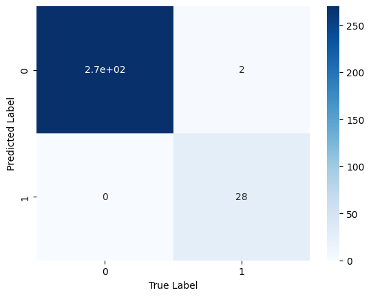

```python
# the confusion matrix of the test and predicted test data
cf_mat = confusion_matrix(y_test, y_pred_test).T
cf_mat
#Plot the heatmap of the confusion matrix
sns.heatmap(cf_mat,annot=True,cmap='Blues')
plt.xlabel('True Label')
plt.ylabel('Predicted Label')
plt.show()
```

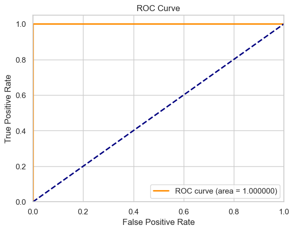

```python
# ROC curve
y_valid_score=logreg.decision_function(X_test)

# compute ROC curve
fpr, tpr, thresholds = roc_curve(y_test,y_valid_score)
roc_auc = auc(fpr, tpr)

# plot the graph of ROC curve
sns.set_theme(style="whitegrid")
plt.plot(fpr, tpr, color='darkorange', lw=2, label='ROC curve (area = %f)' % roc_auc)
plt.plot([0, 1], [0, 1], color='navy', lw=2, linestyle='--')
plt.xlim([0.0, 1.0])
plt.ylim([0.0, 1.05])
plt.xlabel('False Positive Rate')
plt.ylabel('True Positive Rate')
plt.title('ROC Curve')
plt.legend(loc="lower right")
```

## Part 4. Business Insights

### 4.1. Recommendation for opening new courses in the university

This part will use scraping to get all the courses available and recommend the school which course should be opened to adjust the need for our job.

We choose UC Berkeley as the example.

#### 4.1.1 Scraping the data

- We use technology of scraping to get the data from CS department of UC Berkeley
- The URL is "https://www2.eecs.berkeley.edu/Courses/CS/"

```python
from bs4 import BeautifulSoup
import requests


url = "https://www2.eecs.berkeley.edu/Courses/CS/"
r = requests.get(url)
soup = BeautifulSoup(r.content, 'html.parser')

s = soup('p')

des = []
for ele in s:
    # remove <strong> element
    for strong in ele.find_all('strong'):
        strong.decompose()
    des.append(ele.text)

    des_clean = []

# remove the \n string
for str in des:
    for char in str:
        if char == '\n':
            str = str.replace(char, '')
    des_clean.append(str)

# remove the continuous space
for i in range(len(des_clean)):
    des_clean[i] = ' '.join(des_clean[i].split())

s = soup('a')

course_name = []
for ele in s:
    if ele.has_attr('href') and "Courses" in ele['href']:
        course_name.append(ele.text)

df5 = pd.DataFrame(columns=['course', 'description'])

for i in range(len(course_name)):
    df5 = df5.append({'course': course_name[i], 'description': des_clean[i]}, ignore_index=True)
```

Show the scraped data

```python
df5.head()
```

|  | course | description |
| --- | --- | --- |
| 0 | CS 2. Topics in Computer Science | This is a seminar course in which computer sci... |
| 1 | CS 3. Introduction to Symbolic Programming | Introduction to computer programming, emphasiz... |
| 2 | CS 3L. Introduction to Symbolic Programming | Introduction to computer programming, emphasiz... |
| 3 | CS 3S. Introduction to Symbolic Programming (S... | The same material as 3 but in a self-paced for... |
| 4 | CS C8. Foundations of Data Science | Foundations of data science from three perspec... |

#### 4.1.2 Output matched courses and recommend the school to open new courses that match the skills

```python
hard_skills = [i[1] for i in hard_skills_required]
soft_skills = [i[1] for i in soft_skills_required]

coures = []
recommendation = hard_skills+soft_skills
print("Student can take those courses if they want to gain those skills:")
#print(soft_skills)
#print(hard_skills)
print("------------------------------------------------------------------------------------------------------------------")

#str(soft_skills)
for i in range(len(df5)):
    recmd = []
    fix_skill = []
    is_fix = False

    desp = df5.iloc[i,1].lower().replace(',', ' ').replace('.', ' ').replace('!', ' ').replace('  ', ' ').split(' ')
    for skill in hard_skills:
        for j in desp:
            if j == skill and j != '':
                # print(j,skill)
                is_fix = True
                break
        if is_fix==True:
            fix_skill.append(skill)
        else:
            recmd.append(skill)

    is_fix2 = False
    for skill in soft_skills:
        for j in desp:
            if j == skill and j != '':
                is_fix2 = True
                break
        if is_fix2:
            fix_skill.append(skill)
        else:
            recmd.append(skill)


    if is_fix or is_fix2:
        print(df5.iloc[i,0],":",','.join(fix_skill))


    recommendation = set(recommendation)&set(recmd)

print("------------------------------------------------------------------------------------------------------------------")
print("\nWe recommend the university should open these courses:")
if len(recommendation) != 0:
    for i in recommendation:
        print(i)
```

```
Student can take those courses if they want to gain those skills:
------------------------------------------------------------------------------------------------------------------
CS 3. Introduction to Symbolic Programming : project,algorithms,sql,analytics
CS 3L. Introduction to Symbolic Programming : project,algorithms,sql,analytics
CS N10. The Beauty and Joy of Computing : project,algorithms,sql,analytics
CS W10. The Beauty and Joy of Computing : project,algorithms,sql,analytics
CS 47B. Completion of Work in Computer Science 61B : management,law,writing
CS 61A. The Structure and Interpretation of Computer Programs : algorithms,sql,analytics
CS 61AS. The Structure and Interpretation of Computer Programs (Self-Paced) : algorithms,sql,analytics
CS W61A. The Structure and Interpretation of Computer Programs  (Online) : algorithms,sql,analytics
CS 61B. Data Structures : algorithms,sql,analytics,management,law,writing
CS 61C. Machine Structures : management,law,writing
CS 70. Discrete Mathematics and Probability Theory : law,writing
CS C88C. Computational Structures in Data Science : algorithms,sql,analytics
CS C100. Principles & Techniques of Data Science : algorithms,sql,analytics
CS 146L. Programmable Digital Systems Laboratory : project,algorithms,sql,analytics
CS 162. Operating Systems and System Programming : communication,management,law,writing
CS 167. Introduction to Distributed Systems : project,algorithms,sql,analytics
CS 168. Introduction to the Internet: Architecture and Protocols : algorithms,sql,analytics
CS 169. Software Engineering : project,algorithms,sql,analytics,management,law,writing
CS 169A. Introduction to Software Engineering : project,algorithms,sql,analytics,management,law,writing
CS W169A. Software Engineering : project,algorithms,sql,analytics,management,law,writing
CS 169L. Software Engineering Team Project : project,algorithms,sql,analytics,communication,management,law,writing
CS 170. Efficient Algorithms and Intractable Problems : algorithms,sql,analytics
CS 171. Cryptography : algorithms,sql,analytics,communication,management,law,writing
CS 176. Algorithms for Computational Biology : algorithms,sql,analytics
CS C176. Algorithms for Computational Biology : algorithms,sql,analytics
CS 184. Foundations of Computer Graphics : algorithms,sql,analytics
CS 186. Introduction to Database Systems : project,algorithms,sql,analytics
CS W186. Introduction to Database Systems : sql,analytics,management,law,writing
CS 189. Introduction to Machine Learning : algorithms,sql,analytics
CS 189-001. Introduction to Knowledge-Based Systems and Languages : algorithms,sql,analytics
CS C191. Quantum Information Science and Technology : algorithms,sql,analytics
CS H196. Honors Seminar for Computer Science Majors : project,algorithms,sql,analytics
CS C200A. Principles and Techniques of Data Science : project,algorithms,sql,analytics
CS 252A. Graduate Computer Architecture : project,algorithms,sql,analytics
CS 253. Software Engineering and Artificial Intelligence : project,algorithms,sql,analytics
CS 258. Parallel Processors : communication,management,law,writing
CS 262A. Advanced Topics in Computer Systems : project,algorithms,sql,analytics,management,law,writing
CS 262B. Advanced Topics in Computer Systems : project,algorithms,sql,analytics,management,law,writing
```

[output cut: 19 more lines]

```
CS 289A. Introduction to Machine Learning : algorithms,sql,analytics
CS 302. Designing Computer Science Education : project,algorithms,sql,analytics
EECS 47F. Completion of work in Computer Science 70 : law,writing
EECS 126. Probability and Random Processes : communication,management,law,writing
EECS 151LA. Introduction to Digital Design and Integrated Circuits Lab : project,algorithms,sql,analytics
EECS 151LB. Introduction to Digital Design and Integrated Circuits Lab : project,algorithms,sql,analytics
EECS 208. Computational Principles for High-dimensional Data Analysis : algorithms,sql,analytics
EECS 225A. Statistical Signal Processing : algorithms,sql,analytics
EECS 251LA. Introduction to Digital Design and Integrated Circuits Lab : project,algorithms,sql,analytics
EECS 251LB. Introduction to Digital Design and Integrated Circuits Lab : project,algorithms,sql,analytics
------------------------------------------------------------------------------------------------------------------

We recommend the university should open these courses:
art
machine learning
```

### 4.2 Recommend similar jobs to the clients when searching for a specific job

Use TfidfVectorizer to analyze the correlations between different jobs. Enter one job name, give five most correlated jobs.

```python
# read job dataset


df_job=pd.read_csv("alldata.csv")


df_job.head()
```

|  | position | company | description | reviews | location |
| --- | --- | --- | --- | --- | --- |
| 0 | Development Director | ALS TDI | Development Director\nALS Therapy Development ... | NaN | Atlanta, GA 30301 |
| 1 | An Ostentatiously-Excitable Principal Research... | The Hexagon Lavish | Job Description\n\n"The road that leads to acc... | NaN | Atlanta, GA |
| 2 | Data Scientist | Xpert Staffing | Growing company located in the Atlanta, GA are... | NaN | Atlanta, GA |
| 3 | Data Analyst | Operation HOPE | DEPARTMENT: Program OperationsPOSITION LOCATIO... | 44.0 | Atlanta, GA 30303 |
| 4 | Assistant Professor -TT - Signal Processing & ... | Emory University | DESCRIPTION\nThe Emory University Department o... | 550.0 | Atlanta, GA |

```python
# Merge the job position and  description
df_job['position'] = df_job['position'].fillna('')


df_job['description'] = df_job['description'].fillna('')


df_job['position']=df_job['position'].str.lower()


df_job['description']=df_job['description'].str.lower()


df_job['description'] = df_job['position'] + df_job['description']


df_job.head()
```

|  | position | company | description | reviews | location |
| --- | --- | --- | --- | --- | --- |
| 0 | development director | ALS TDI | development directordevelopment director\nals ... | NaN | Atlanta, GA 30301 |
| 1 | an ostentatiously-excitable principal research... | The Hexagon Lavish | an ostentatiously-excitable principal research... | NaN | Atlanta, GA |
| 2 | data scientist | Xpert Staffing | data scientistgrowing company located in the a... | NaN | Atlanta, GA |
| 3 | data analyst | Operation HOPE | data analystdepartment: program operationsposi... | 44.0 | Atlanta, GA 30303 |
| 4 | assistant professor -tt - signal processing & ... | Emory University | assistant professor -tt - signal processing & ... | 550.0 | Atlanta, GA |

```python
# Use TfidfVectorizer convert the descriptions to a matrix of TF-IDF features
tv1 = TfidfVectorizer(analyzer='word',ngram_range=(1, 2),min_df=0, stop_words='english')


tfidf_matrix1 = tv1.fit_transform(df_job['description'])
#print(tv.get_feature_names)
tfidf_matrix1.shape
```

```
(6964, 751204)
```

This code may take a around 1-2 minutes to run.

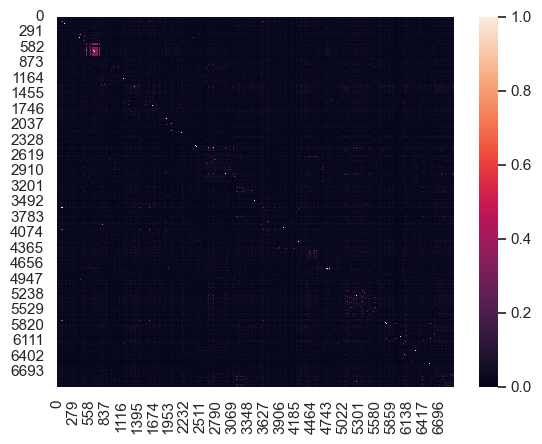

```python
# Calculate the  cosine similarity through the dot product of the tfidf_matrix
cosine_similarity1 = linear_kernel(tfidf_matrix1, tfidf_matrix1)

#Heatmap to show the correlation between the jobs
sns.heatmap(cosine_similarity1)
```

```python
job_names = df_job['position']


indices1 = pd.Series(df_job.index, index=df_job['position'])
```

```python
# Define a function to recommend similar jobs
def get_recommendations1(job):


    job=job.lower()


    idx = indices1[job][0]


    #print(idx)


    sim_scores = list(enumerate(cosine_similarity1[idx]))


#     print(len(sim_scores))


#     print(sim_scores[1][1])


    sim_scores = sorted(sim_scores, key=lambda x: x[1], reverse=True)


    job_indices = [i[0] for i in sim_scores[1:]] # remove the target job itself


    return job_names.iloc[job_indices]
```

```python
# Try to find first five similar jobs of "Research Analyst"

get_recommendations1('Data Scientist').head()
```

```
1880                                       data scientist
6938    data scientist, customer interests & personali...
6939    data scientist, customer interests & personali...
2047    sr principal apps system engineer - data scien...
6753                    enterprise architect data science
Name: position, dtype: object
```

### 4.3 Recommend courses with similar content

Use TfidfVectorizer to analyze the correlations between different courses. Enter one course name, give five most correlated courses teach similiar skills.

```python
# read course dataset


df_course=pd.read_csv("coursera-courses.csv")


df_course.head()
```

|  | course_url | course_name | learning_product_type | course_provided_by | course_rating | course_rated_by | enrolled_student_count | course_difficulty | skills | description | percentage_of_new_career_starts | percentage_of_pay_increase_or_promotion | estimated_time_to_complete | instructors |
| --- | --- | --- | --- | --- | --- | --- | --- | --- | --- | --- | --- | --- | --- | --- |
| 0 | https://www.coursera.org/professional-certific... | IBM Data Science | PROFESSIONAL CERTIFICATE | IBM | 4.6 | 51792.0 | 500000.0 | Beginner | ['Data Science', 'Machine Learning', 'Python P... | Data Science has been ranked as one of the hot... | 46.0 | 19.0 | 10 months | ['Joseph Santarcangelo', 'Alex Aklson', 'Rav A... |
| 1 | https://www.coursera.org/specializations/intro... | Introduction to Data Science | SPECIALIZATION | IBM | 4.6 | 40336.0 | 320000.0 | Beginner | ['Data Science', 'Python Programming', 'Rstudi... | In this Specialization learners will develop f... | 46.0 | 19.0 | 4 months | ['Alex Aklson', 'Rav Ahuja', 'Romeo Kienzler',... |
| 2 | https://www.coursera.org/specializations/python | Python for Everybody | SPECIALIZATION | University of Michigan | 4.8 | 135354.0 | 1500000.0 | Beginner | ['Json', 'Xml', 'Python Programming', 'Databas... | This Specialization builds on the success of t... | 39.0 | 19.0 | 8 months | ['Charles Russell SeveranceTop Instructor'] |
| 3 | https://www.coursera.org/professional-certific... | Google IT Support | PROFESSIONAL CERTIFICATE | Google | 4.8 | 38906.0 | 380000.0 | Beginner | ['Binary Code', 'Customer Support', 'Linux', '... | This 5-course certificate, developed by Google... | NaN | NaN | 8 months | ['GoogleTop Instructor'] |
| 4 | https://www.coursera.org/specializations/deep-... | Deep Learning | SPECIALIZATION | deeplearning.ai | 4.8 | 92961.0 | 720000.0 | Intermediate | ['Tensorflow', 'Convolutional Neural Network',... | If you want to break into AI, this Specializat... | 41.0 | 14.0 | 4 months | ['Andrew NgTop Instructor', 'Head Teaching Ass... |

```python
# Processing the course names and  skills
df_course['skills'] = df_course['skills'].fillna('')


df_course['skills']=df_course['skills'].str.lower()


df_course['course_name']=df_course['course_name'].str.lower()


df_course.head()
```

|  | course_url | course_name | learning_product_type | course_provided_by | course_rating | course_rated_by | enrolled_student_count | course_difficulty | skills | description | percentage_of_new_career_starts | percentage_of_pay_increase_or_promotion | estimated_time_to_complete | instructors |
| --- | --- | --- | --- | --- | --- | --- | --- | --- | --- | --- | --- | --- | --- | --- |
| 0 | https://www.coursera.org/professional-certific... | ibm data science | PROFESSIONAL CERTIFICATE | IBM | 4.6 | 51792.0 | 500000.0 | Beginner | ['data science', 'machine learning', 'python p... | Data Science has been ranked as one of the hot... | 46.0 | 19.0 | 10 months | ['Joseph Santarcangelo', 'Alex Aklson', 'Rav A... |
| 1 | https://www.coursera.org/specializations/intro... | introduction to data science | SPECIALIZATION | IBM | 4.6 | 40336.0 | 320000.0 | Beginner | ['data science', 'python programming', 'rstudi... | In this Specialization learners will develop f... | 46.0 | 19.0 | 4 months | ['Alex Aklson', 'Rav Ahuja', 'Romeo Kienzler',... |
| 2 | https://www.coursera.org/specializations/python | python for everybody | SPECIALIZATION | University of Michigan | 4.8 | 135354.0 | 1500000.0 | Beginner | ['json', 'xml', 'python programming', 'databas... | This Specialization builds on the success of t... | 39.0 | 19.0 | 8 months | ['Charles Russell SeveranceTop Instructor'] |
| 3 | https://www.coursera.org/professional-certific... | google it support | PROFESSIONAL CERTIFICATE | Google | 4.8 | 38906.0 | 380000.0 | Beginner | ['binary code', 'customer support', 'linux', '... | This 5-course certificate, developed by Google... | NaN | NaN | 8 months | ['GoogleTop Instructor'] |
| 4 | https://www.coursera.org/specializations/deep-... | deep learning | SPECIALIZATION | deeplearning.ai | 4.8 | 92961.0 | 720000.0 | Intermediate | ['tensorflow', 'convolutional neural network',... | If you want to break into AI, this Specializat... | 41.0 | 14.0 | 4 months | ['Andrew NgTop Instructor', 'Head Teaching Ass... |

```python
# Use TfidfVectorizer convert the descriptions to a matrix of TF-IDF features
tv = TfidfVectorizer(analyzer='word',ngram_range=(1, 2),min_df=0, stop_words='english')


tfidf_matrix = tv.fit_transform(df_course["skills"])
#print(tv.get_feature_names)
tfidf_matrix.shape
```

```
(1000, 6112)
```

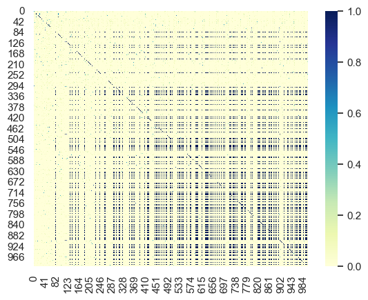

```python
# Calculate the  cosine similarity through the dot product of the tfidf_matrix
cosine_similarity = linear_kernel(tfidf_matrix, tfidf_matrix)

#Heatmap to show the correlation between the courses
# change the color map to "YlGnBu" to make it more readable
sns.heatmap(cosine_similarity, cmap="YlGnBu")
```

```python
course_names = df_course['course_name']


indices = pd.Series(df_course.index, index=df_course['course_name'])
```

```python
# Define a function to recommend similar courses that can learn similar skills
def get_recommendations(course):


    course=course.lower()

    #print(course)
    idx = indices[course]


    #print(idx)


    sim_scores = list(enumerate(cosine_similarity[idx]))


#     print(len(sim_scores))


#     print(sim_scores[1][1])


    sim_scores = sorted(sim_scores, key=lambda x: x[1], reverse=True)


    course_indices = [i[0] for i in sim_scores[1:]] #exclude the course name itself, which correlation =1


    return course_names.iloc[course_indices]
```

```python
# Try to find first five similar courses of "Google IT Support"
get_recommendations('Google IT Support').head()
```

```
448    system administration and it infrastructure se...
43                        technical support fundamentals
336     operating systems and you: becoming a power user
148            the bits and bytes of computer networking
648                             version control with git
Name: course_name, dtype: object
```